# If not me, then who? Responsibility and replacement

## 4.2 Models

### 4.2.1 Agent condition

#### 4.2.1.1 Parameter search

Uniform probabilities:

```r
rmse.exp2.agent_uniform = data.frame()
for (p in seq(0, 1, by = 0.05)) {
  rmse.exp2.agent_uniform = update_search_one(2, 'agent', p)
}
colnames(rmse.exp2.agent_uniform) = c('p', 'rmse')

# get optimal values
p.exp2.agent = rmse.exp2.agent_uniform[which.min(rmse.exp2.agent_uniform$rmse),]$p

# create plot
plot_rmse.exp2.agent_uniform = plot_search_one(2, 'agent')

# update response data
data.exp2.agent = data.exp2.agent %>%
  mutate(prob_uniform = 1 - (1 - p.exp2.agent)^num)
```

Varying probabilities:

```r
rmse.exp2.agent_full = data.frame()
for (p_low in seq(0, 1, by = 0.05)) {
  for (p_high in seq(p_low, 1, by = 0.05)) {
    rmse.exp2.agent_full = update_search_two(2, 'agent', p_low, p_high)
  }
}
colnames(rmse.exp2.agent_full) = c('p_low', 'p_high', 'rmse')

# get optimal values
p.exp2.agent_low = rmse.exp2.agent_full[which.min(rmse.exp2.agent_full$rmse),]$p_low
p.exp2.agent_high = rmse.exp2.agent_full[which.min(rmse.exp2.agent_full$rmse),]$p_high

# create plot
plot_rmse.exp2.agent_full = plot_search_two(2, 'agent')

# update response data
data.exp2.agent = data.exp2.agent %>%
  mutate(prob_full = 1 - (1 - p.exp2.agent_low)^low * (1 - p.exp2.agent_high)^high)
```

#### 4.2.1.2 Overall models

Fitting baseline model:

```r
fit.exp2.agent_baseline = brm(
  formula = resp ~ 1 + (1 | id),
  data = data.exp2.agent,
  iter = 8000,
  seed = 1,
  file = "cache/fit.exp2.agent_baseline")
```

Fitting CRM (uniform):

```r
fit.exp2.agent_crm_uniform = brm(
  formula = resp ~ 1 + prob_uniform + (1 + prob_uniform | id),
  data = data.exp2.agent,
  iter = 8000,
  seed = 1,
  file = "cache/fit.exp2.agent_crm_uniform")
```

Fitting CRM (full):

```r
fit.exp2.agent_crm_full = brm(
  formula = resp ~ 1 + prob_full + (1 + prob_full | id),
  data = data.exp2.agent,
  iter = 8000,
  seed = 1,
  file = "cache/fit.exp2.agent_crm_full")
```

Comparing models with leave-one-out cross-validation:

```r
fit.exp2.agent_baseline = add_criterion(
  fit.exp2.agent_baseline,
  criterion = "loo",
  reloo = T,
  file = "cache/fit.exp2.agent_baseline")

fit.exp2.agent_crm_uniform = add_criterion(
  fit.exp2.agent_crm_uniform,
  criterion = "loo",
  reloo = T,
  file = "cache/fit.exp2.agent_crm_uniform")

fit.exp2.agent_crm_full = add_criterion(
  fit.exp2.agent_crm_full,
  criterion = "loo",
  reloo = T,
  file = "cache/fit.exp2.agent_crm_full")

loo_compare(fit.exp2.agent_baseline,
            fit.exp2.agent_crm_uniform,
            fit.exp2.agent_crm_full)
```

```
##                            elpd_diff se_diff
## fit.exp2.agent_crm_full       0.0       0.0
## fit.exp2.agent_crm_uniform -411.7      35.9
## fit.exp2.agent_baseline    -586.4      40.2
```

#### 4.2.1.3 Individual models

```r
prior = c(prior(normal(0, 20), class = 'b', ub = 0))

fit.exp2.agent_baseline_individual = brm(
  formula = resp ~ 1,
  data = data.exp2.agent %>%
    filter(plot_id == 1),
  seed = 1,
  file = "cache/fit.exp2.agent_baseline_individual")

fit.exp2.agent_crm_uniform_individual = brm(
  formula = resp ~ 1 + prob_uniform,
  data = data.exp2.agent %>%
    filter(plot_id == 1),
  prior = prior,
  seed = 1,
  file = "cache/fit.exp2.agent_crm_uniform_individual")

fit.exp2.agent_crm_full_individual = brm(
  formula = resp ~ 1 + prob_full,
  data = data.exp2.agent %>%
    filter(plot_id == 1),
  prior = prior,
  seed = 1,
  file = "cache/fit.exp2.agent_crm_full_individual")

# update model fits for each participant
data.exp2.agent_model_fits = data.exp2.agent %>%
  group_by(plot_id) %>%
  nest() %>%
  ungroup() %>%
  mutate(fit_baseline = map(.x = data,
                            .f = ~ update(fit.exp2.agent_baseline_individual,
                                          newdata = .x,
                                          seed = 1)),
         fit_crm_uniform = map(.x = data,
                               .f = ~ update(fit.exp2.agent_crm_uniform_individual,
                                             newdata = .x,
                                             seed = 1)),
         fit_crm_full = map(.x = data,
                            .f = ~ update(fit.exp2.agent_crm_full_individual,
                                          newdata = .x,
                                          seed = 1))) %>%
  mutate(fit_baseline = map(.x = fit_baseline,
                            .f = ~ add_criterion(.x, criterion = "loo")),
         fit_crm_uniform = map(.x = fit_crm_uniform,
                               .f = ~ add_criterion(.x, criterion = "loo")),
         fit_crm_full = map(.x = fit_crm_full,
                            .f = ~ add_criterion(.x, criterion = "loo")),
         model_comparison = pmap(.l = list(baseline = fit_baseline,
                                           crm_uniform = fit_crm_uniform,
                                           crm_full = fit_crm_full),
                                 .f = ~ loo_compare(..1, ..2, ..3)),
         best_model = map_chr(.x = model_comparison,
                              .f = ~ rownames(.) %>%
                                .[1]),
         best_model = factor(best_model,
                             levels = c("..1", "..2", "..3"),
                             labels = c("baseline",
                                        "crm_uniform",
                                        "crm_full")))

save(list = c("data.exp2.agent_model_fits"),
     file = paste0(data_dir, 'experiment2_agent/model-fits.RData'))
```

```r
load(file = paste0(data_dir, 'experiment2_agent/model-fits.RData'))

data.exp2.agent_model_fits %>%
  count(best_model) %>%
  arrange(desc(n))
```

```
## # A tibble: 3 × 2
##   best_model      n
##   <fct>       <int>
## 1 crm_full       26
## 2 baseline       17
## 3 crm_uniform     7
```

### 4.2.2 Object condition

#### 4.2.2.1 Parameter search

Uniform probabilities:

```r
rmse.exp2.object_uniform = data.frame()
for (p in seq(0, 1, by = 0.05)) {
  rmse.exp2.object_uniform = update_search_one(2, 'object', p)
}
colnames(rmse.exp2.object_uniform) = c('p', 'rmse')

# get optimal values
p.exp2.object = rmse.exp2.object_uniform[which.min(rmse.exp2.object_uniform$rmse),]$p

# create plot
plot_rmse.exp2.object_uniform = plot_search_one(2, 'object')

# update response data
data.exp2.object = data.exp2.object %>%
  mutate(prob_uniform = 1 - (1 - p.exp2.object)^num)
```

Varying probabilities:

```r
rmse.exp2.object_full = data.frame()
for (p_low in seq(0, 1, by = 0.05)) {
  for (p_high in seq(p_low, 1, by = 0.05)) {
    rmse.exp2.object_full = update_search_two(2, 'object', p_low, p_high)
  }
}
colnames(rmse.exp2.object_full) = c('p_low', 'p_high', 'rmse')

# get optimal values
p.exp2.object_low = rmse.exp2.object_full[which.min(rmse.exp2.object_full$rmse),]$p_low
p.exp2.object_high = rmse.exp2.object_full[which.min(rmse.exp2.object_full$rmse),]$p_high

# create plot
plot_rmse.exp2.object_full = plot_search_two(2, 'object')

# update response data
data.exp2.object = data.exp2.object %>%
  mutate(prob_full = 1 - (1 - p.exp2.object_low)^low * (1 - p.exp2.object_high)^high)
```

#### 4.2.2.2 Overall models

Fitting baseline model:

```r
fit.exp2.object_baseline = brm(
  formula = resp ~ 1 + (1 | id),
  data = data.exp2.object,
  iter = 8000,
  seed = 1,
  file = "cache/fit.exp2.object_baseline")
```

Fitting CRM (uniform):

```r
fit.exp2.object_crm_uniform = brm(
  formula = resp ~ 1 + prob_uniform + (1 + prob_uniform | id),
  data = data.exp2.object,
  iter = 8000,
  seed = 1,
  file = "cache/fit.exp2.object_crm_uniform")
```

Fitting CRM (full):

```r
fit.exp2.object_crm_full = brm(
  formula = resp ~ 1 + prob_full + (1 + prob_full | id),
  data = data.exp2.object,
  iter = 8000,
  seed = 1,
  file = "cache/fit.exp2.object_crm_full")
```

Comparing models with leave-one-out cross-validation:

```r
fit.exp2.object_baseline = add_criterion(
  fit.exp2.object_baseline,
  criterion = "loo",
  reloo = T,
  file = "cache/fit.exp2.object_baseline")

fit.exp2.object_crm_uniform = add_criterion(
  fit.exp2.object_crm_uniform,
  criterion = "loo",
  reloo = T,
  file = "cache/fit.exp2.object_crm_uniform")

fit.exp2.object_crm_full = add_criterion(
  fit.exp2.object_crm_full,
  criterion = "loo",
  reloo = T,
  file = "cache/fit.exp2.object_crm_full")

loo_compare(fit.exp2.object_baseline,
            fit.exp2.object_crm_uniform,
            fit.exp2.object_crm_full)
```

```
##                             elpd_diff se_diff
## fit.exp2.object_crm_full       0.0       0.0
## fit.exp2.object_crm_uniform  -61.8       6.8
## fit.exp2.object_baseline    -307.3      24.8
```

#### 4.2.2.3 Individual models

```r
prior = c(prior(normal(0, 20), class = 'b', ub = 0))

fit.exp2.object_baseline_individual = brm(
  formula = resp ~ 1,
  data = data.exp2.object %>%
    filter(plot_id == 1),
  seed = 1,
  file = "cache/fit.exp2.object_baseline_individual")

fit.exp2.object_crm_uniform_individual = brm(
  formula = resp ~ 1 + prob_uniform,
  data = data.exp2.object %>%
    filter(plot_id == 1),
  prior = prior,
  seed = 1,
  file = "cache/fit.exp2.object_crm_uniform_individual")

fit.exp2.object_crm_full_individual = brm(
  formula = resp ~ 1 + prob_full,
  data = data.exp2.object %>%
    filter(plot_id == 1),
  prior = prior,
  seed = 1,
  file = "cache/fit.exp2.object_crm_full_individual")

# update model fits for each participant
data.exp2.object_model_fits = data.exp2.object %>%
  group_by(plot_id) %>%
  nest() %>%
  ungroup() %>%
  mutate(fit_baseline = map(.x = data,
                            .f = ~ update(fit.exp2.object_baseline_individual,
                                          newdata = .x,
                                          seed = 1)),
         fit_crm_uniform = map(.x = data,
                               .f = ~ update(fit.exp2.object_crm_uniform_individual,
                                             newdata = .x,
                                             seed = 1)),
         fit_crm_full = map(.x = data,
                            .f = ~ update(fit.exp2.object_crm_full_individual,
                                          newdata = .x,
                                          seed = 1))) %>%
  mutate(fit_baseline = map(.x = fit_baseline,
                            .f = ~ add_criterion(.x, criterion = "loo")),
         fit_crm_uniform = map(.x = fit_crm_uniform,
                               .f = ~ add_criterion(.x, criterion = "loo")),
         fit_crm_full = map(.x = fit_crm_full,
                            .f = ~ add_criterion(.x, criterion = "loo")),
         model_comparison = pmap(.l = list(baseline = fit_baseline,
                                           crm_uniform = fit_crm_uniform,
                                           crm_full = fit_crm_full),
                                 .f = ~ loo_compare(..1, ..2, ..3)),
         best_model = map_chr(.x = model_comparison,
                              .f = ~ rownames(.) %>%
                                .[1]),
         best_model = factor(best_model,
                             levels = c("..1", "..2", "..3"),
                             labels = c("baseline",
                                        "crm_uniform",
                                        "crm_full")))

save(list = c("data.exp2.object_model_fits"),
     file = paste0(data_dir, 'experiment2_object/model-fits.RData'))
```

```r
load(file = paste0(data_dir, 'experiment2_object/model-fits.RData'))

data.exp2.object_model_fits %>%
  count(best_model) %>%
  arrange(desc(n))
```

```
## # A tibble: 3 × 2
##   best_model      n
##   <fct>       <int>
## 1 crm_full       21
## 2 baseline       16
## 3 crm_uniform    13
```

## 4.3 Plots

### 4.3.1 Parameter search

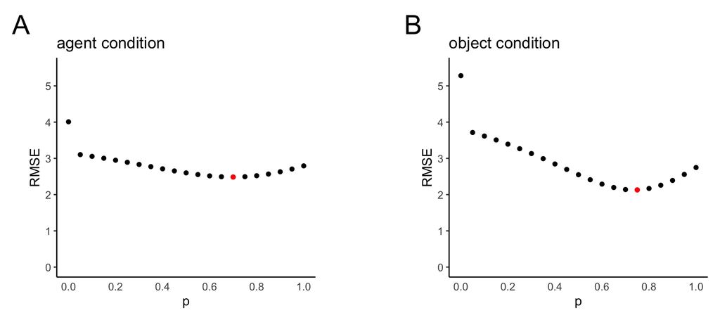

```r
plot_rmse.exp2.agent_uniform + plot_spacer() + plot_rmse.exp2.object_uniform +
  plot_annotation(tag_levels = 'A') +
  plot_layout(widths = c(4, 1, 4)) &
  theme(plot.tag = element_text(size = 24))
```

```r
# ggsave(paste0(figures_dir, 'experiment2/p_search_uniform.pdf'), width = 9, height = 4)
```

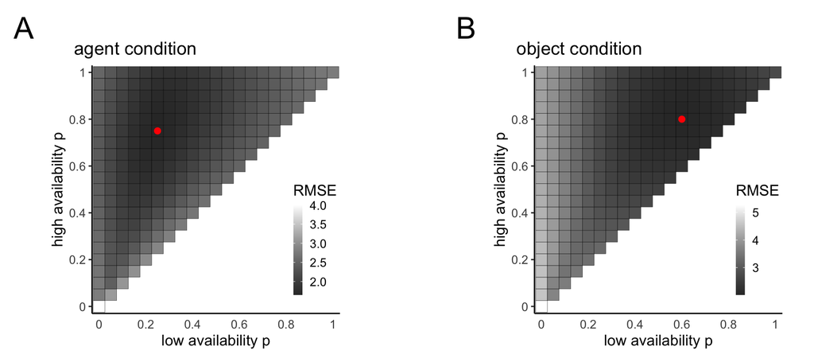

```r
plot_rmse.exp2.agent_full + plot_spacer() + plot_rmse.exp2.object_full +
  plot_annotation(tag_levels = 'A') +
  plot_layout(widths = c(4, 1, 4)) &
  theme(plot.tag = element_text(size = 24))
```

```r
# ggsave(paste0(figures_dir, 'experiment2/p_search_full.pdf'), width = 9, height = 4)
```

### 4.3.2 Setting up data

```r
data.exp2.agent = data.exp2.agent %>%
  cbind(fit.exp2.agent_baseline %>%
          fitted(newdata = data.exp2.agent,
                 re_formula = NA) %>%
          as_tibble() %>%
          mutate(pred_baseline = Estimate) %>%
          select(pred_baseline)) %>%
  cbind(fit.exp2.agent_crm_uniform %>%
          fitted(newdata = data.exp2.agent,
                 re_formula = NA) %>%
          as_tibble() %>%
          mutate(pred_crm_uniform = Estimate) %>%
          select(pred_crm_uniform)) %>%
  cbind(fit.exp2.agent_crm_full %>%
          fitted(newdata = data.exp2.agent,
                 re_formula = NA) %>%
          as_tibble() %>%
          mutate(pred_crm_full = Estimate) %>%
          select(pred_crm_full))

data.exp2.agent_means = data.exp2.agent %>%
  group_by(trial, craft) %>%
  summarise(resp_mean = mean(resp),
            resp_low = smean.cl.boot(resp)[2],
            resp_high = smean.cl.boot(resp)[3]) %>%
  merge(info.exp2.agent, by = c('trial', 'craft')) %>%
  left_join(data.exp2.agent %>%
              distinct(trial, craft, pred_baseline,
                       pred_crm_uniform, pred_crm_full),
            by = c('trial', 'craft'))
```

```r
data.exp2.object = data.exp2.object  %>%
  cbind(fit.exp2.object_baseline %>%
          fitted(newdata = data.exp2.object ,
                 re_formula = NA) %>%
          as_tibble() %>%
          mutate(pred_baseline = Estimate) %>%
          select(pred_baseline)) %>%
  cbind(fit.exp2.object_crm_uniform %>%
          fitted(newdata = data.exp2.object ,
                 re_formula = NA) %>%
          as_tibble() %>%
          mutate(pred_crm_uniform = Estimate) %>%
          select(pred_crm_uniform)) %>%
  cbind(fit.exp2.object_crm_full %>%
          fitted(newdata = data.exp2.object ,
                 re_formula = NA) %>%
          as_tibble() %>%
          mutate(pred_crm_full = Estimate) %>%
          select(pred_crm_full))

data.exp2.object_means = data.exp2.object  %>%
  group_by(trial, color) %>%
  summarise(resp_mean = mean(resp),
            resp_low = smean.cl.boot(resp)[2],
            resp_high = smean.cl.boot(resp)[3]) %>%
  merge(info.exp2.object, by = c('trial', 'color')) %>%
  left_join(data.exp2.object  %>%
              distinct(trial, color, pred_baseline,
                       pred_crm_uniform, pred_crm_full),
            by = c('trial', 'color'))
```

```r
labels.exp2 = info.exp2.agent %>%
  distinct(low, high, num) %>%
  arrange(num, high) %>%
  mutate(condition = NA,
         index = 1:n(),
         grob = map2(.x = low,
                     .y = high,
                     .f = ~ readPNG(paste0(figures_dir, 'experiment2/sets/',
                                           .x, .y, '.png'))))

model_labels.exp2 = c('baseline' = 'Contribution model',
                      'crm_uniform' = 'CRM (uniform)',
                      'crm_full' = 'CRM (full)')

model_order.exp2 = c('baseline', 'crm_uniform', 'crm_full')
```

### 4.3.3 Scatter plots

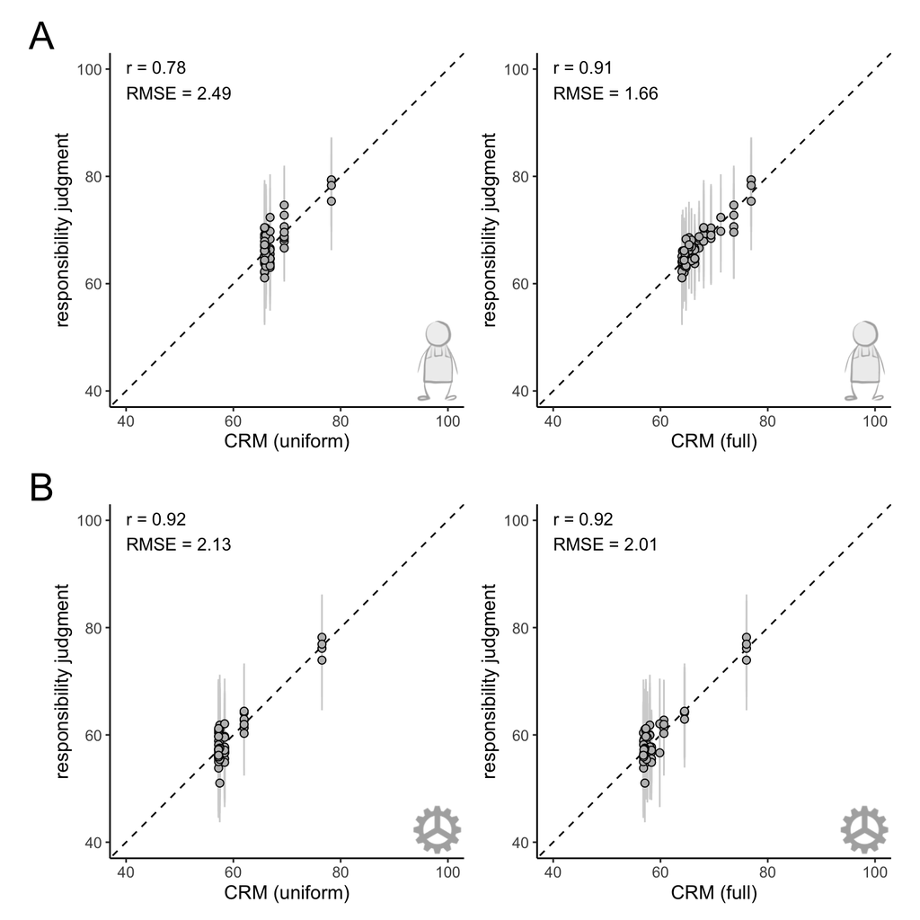

```r
scatter.exp2.agent_uniform = make_scatter(
  data.exp2.agent_means, 'crm_uniform', 'CRM (uniform)', seq(40, 100, 20))
scatter.exp2.agent_full = make_scatter(
  data.exp2.agent_means, 'crm_full', 'CRM (full)', seq(40, 100, 20))

scatter.exp2.object_uniform = make_scatter(
  data.exp2.object_means, 'crm_uniform', 'CRM (uniform)', seq(40, 100, 20))
scatter.exp2.object_full = make_scatter(
  data.exp2.object_means, 'crm_full', 'CRM (full)', seq(40, 100, 20))

scatter.exp2.agent_uniform + inset_element(agent_icon, 0.85, 0.01, 1, 0.25) +
  scatter.exp2.agent_full + inset_element(agent_icon, 0.85, 0.01, 1, 0.25) +
  scatter.exp2.object_uniform + inset_element(object_icon, 0.85, 0.01, 1, 0.15) +
  scatter.exp2.object_full + inset_element(object_icon, 0.85, 0.01, 1, 0.15) +
  plot_layout(ncol = 2) +
  plot_annotation(tag_levels = list(c('A', '', '', '',
                                      'B', '', '', ''))) &
  theme(plot.title = element_text(hjust = 0.5),
        plot.tag = element_text(size = 24))
```

```r
# ggsave(paste0(figures_dir, 'experiment2/scatter.pdf'), width = 8, height = 8)
```

### 4.3.4 Bar plots

```r
make_bar.exp2 = function(data, fill) {
  g = ggplot(data = data,
             mapping = aes(x = index,
                           y = resp)) +
    stat_summary(fun = "mean",
                 geom = "bar",
                 color = 'black',
                 fill = fill,
                 width = 0.8) +
    stat_summary(fun.data = "mean_cl_boot",
                 geom = "linerange",
                 size = 1) +
    stat_summary(mapping = aes(y = pred,
                               fill = model,
                               shape = model,
                               size = model),
                 fun = 'mean',
                 geom = 'point',
                 color = 'black',
                 position = position_dodge(width = 0.5)) +
    facet_wrap(~ index, scales = 'free_x', nrow = 1) +
    geom_rect(aes(xmin = index - 0.5, xmax = index + 0.5,
                  ymin = 0, ymax = 39.9),
              fill = 'white') +
    geom_custom(data = labels.exp2,
                mapping = aes(data = grob,
                              x = -Inf, y = 36),
                grob_fun = function(x) rasterGrob(x,
                                                  interpolate = T,
                                                  vjust = 0,
                                                  hjust = 0)) +
    geom_text(aes(label = index,
                  y = 33),
              show.legend = F,
              check_overlap = T) +
    theme(text = element_text(size = 16),
          legend.position = c(0.5, 0.87),
          legend.direction = 'horizontal',
          legend.title = element_blank(),
          axis.title.x = element_blank(),
          axis.text.x = element_blank(),
          axis.line.x = element_blank(),
          axis.ticks.x = element_blank(),
          strip.background = element_blank(),
          strip.text = element_blank(),
          panel.grid.major.y = element_line(),
          panel.spacing.x = unit(0.1, "cm"),
          plot.margin = margin(t = 0.2, l = 0.2, r = 0.2, b = 0.9, unit = "cm")) +
    scale_fill_manual(values = c('baseline' = 'black',
                                 'crm_uniform' = 'gray50',
                                 'crm_full' = 'white'),
                      labels = model_labels.exp2,
                      name = 'model') +
    scale_size_manual(values = c('baseline' = 1.5,
                                 'crm_uniform' = 1.5,
                                 'crm_full' = 2),
                      labels = model_labels.exp2,
                      name = 'model') +
    scale_shape_manual(values = c('baseline' = 21,  # circle
                                  'crm_uniform' = 24, # triangle
                                  'crm_full' = 23), # diamond
                       labels = model_labels.exp2,
                       name = 'model') +
    scale_y_continuous(name = 'responsibility judgment',
                       breaks = seq(40, 100, 20)) +
    coord_cartesian(clip = 'off', ylim = c(40, 100))

  return(g)
}
```

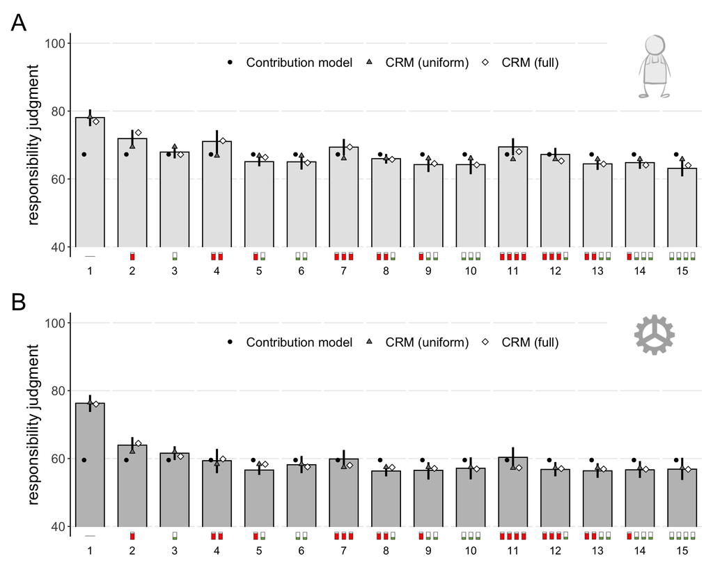

```r
bar.exp2.agent = make_bar.exp2(
  data = data.exp2.agent %>%
    left_join(labels.exp2 %>%
                select(low, high, index),
              by = c('low', 'high')) %>%
    pivot_longer(cols = starts_with('pred'),
                 names_to = 'model',
                 values_to = 'pred') %>%
    mutate(model = factor(sub('^pred_', '', model),
                          levels = model_order.exp2)),
  fill = 'gray90'
)

bar.exp2.object = make_bar.exp2(
  data = data.exp2.object %>%
    left_join(labels.exp2 %>%
                select(low, high, index),
              by = c('low', 'high')) %>%
    pivot_longer(cols = starts_with('pred'),
                 names_to = 'model',
                 values_to =  'pred') %>%
    mutate(model = factor(sub('^pred_', '', model),
                          levels = model_order.exp2)),
  fill = 'gray75'
)

bar.exp2.agent + inset_element(agent_icon, 0.85, 0.7, 1, 1) +
  bar.exp2.object + inset_element(object_icon, 0.85, 0.8, 1, 1) +
  plot_layout(ncol = 1) +
  plot_annotation(tag_levels = list(c('A', '', 'B', ''))) &
  theme(plot.tag = element_text(size = 24))
```

```r
# ggsave(paste0(figures_dir, 'experiment2/bar.pdf'), width = 10, height = 8)
```

# 5 Experiment 3

## 5.1 Data

### 5.1.1 Agent condition

#### 5.1.1.1 Trial info

```r
info.exp3.agent = read_csv(paste0(data_dir, 'experiment3_agent/trial_info.csv'),
                           show_col_types = F) %>%
  pivot_longer(cols = !trial,
               names_to = c('.value', 'craft'),
               names_pattern = '(.+)_(.)') %>%
  mutate(num = low + high)
```

#### 5.1.1.2 Response data

```r
data.exp3.agent = read_csv(paste0(data_dir, 'experiment3_agent/trials.csv'),
                           show_col_types = F)

# filter participants who accidentally responded more than once
rm_ids_agent = data.exp3.agent %>%
  group_by(id) %>%
  summarise(n = n()/length(unique(info.exp3.agent$trial))) %>%
  filter(n > 1) %>%
  .$id

data.exp3.agent = data.exp3.agent %>%
  filter(!(id %in% rm_ids_agent)) %>%
  pivot_longer(cols = c(c, t),
               names_to = 'craft',
               values_to = 'resp') %>%
  # ignore exclusion trial and practice trials
  filter(!(trial %in% c("X1", 1, 2))) %>%
  # merge with trial info
  merge(info.exp3.agent,
        by = c('trial', 'craft')) %>%
  # factor variables for plotting
  mutate(id = factor(id),
         plot_id = as.factor(as.integer(id)),
         craft = factor(craft))
```

Number of participants:

```r
length(unique(data.exp3.agent$id))
```

```
## [1] 50
```

#### 5.1.1.3 Participant data

Participants were asked: “What factors influenced how you decided to respond? Do you have any questions or comments regarding the experiment?”

```r
participants.exp3.agent = read_csv(paste0(data_dir, 'experiment3_agent/participants.csv'),
                                   show_col_types = F) %>%
  filter(id %in% data.exp3.agent$id) %>%
  mutate(id = factor(id)) %>%
  left_join(data.exp3.agent %>%
              distinct(id, plot_id),
            by = 'id')

participants.exp3.agent %>%
  select(plot_id, feedback) %>%
  datatable()
```

|  | plot_id | feedback |
| --- | --- | --- |
| 1 | 5 | Since each craftsman agreed to do their essential step why would there be a difference in responsibility when each person is tasked with a necessary job. |
| 2 | 10 | I think that because both positions were said to be necessary, I placed both workers close to equal importance most of the time. I placed one worker as slightly more important over the other when they… |
| 3 | 4 | I believe that it does not matter how busy the people are or how many available workers there were -- each craftsperson had a choice, and because they each said yes and did their part, they were both … |
| 4 | 9 | Every single time, I said that both craftsmen were very much responsible for the success no matter how busy one of them was or how many craftspeople of each type resided on their respective islands be… |
| 5 | 13 |  |
| 6 | 3 |  |
| 7 | 8 | The availability of each tailor and carpenter. |
| 8 | 14 |  |
| 9 | 11 | Was this person taking on too much work? Was there anyone else that could've taken the job for them based off of workload (green bar)? Are they the only person on their team who is willing/able to do … |
| 10 | 2 | #NAME? |

[output cut: 40 more lines]

### 5.1.2 Object condition

#### 5.1.2.1 Trial info

```r
info.exp3.object = read_csv(paste0(data_dir, 'experiment3_object/trial_info.csv'),
                            show_col_types = F) %>%
  pivot_longer(cols = !trial,
               names_to = c('.value', 'color'),
               names_pattern = '(.+)_(.)') %>%
  mutate(num = low + high)
```

#### 5.1.2.2 Response data

```r
data.exp3.object = read_csv(paste0(data_dir, 'experiment3_object/trials.csv'),
                            show_col_types = F)

# filter participants who accidentally responded more than once
rm_ids_object = data.exp3.object %>%
  group_by(id) %>%
  summarise(n = n()/length(unique(info.exp3.object$trial))) %>%
  filter(n > 1) %>%
  .$id

data.exp3.object = data.exp3.object %>%
  filter(!(id %in% rm_ids_object)) %>%
  pivot_longer(cols = c(b, y),
               names_to = 'color',
               values_to = 'resp') %>%
  # ignore exclusion trial and practice trials
  filter(!(trial %in% c("X1", 1, 2))) %>%
  # merge with trial info
  merge(info.exp3.object,
        by = c('trial', 'color')) %>%
  # factor variables for plotting
  mutate(id = factor(id),
         plot_id = as.factor(as.integer(id)),
         color = factor(color))
```

Number of participants:

```r
length(unique(data.exp3.object$id))
```

```
## [1] 50
```

#### 5.1.2.3 Participant data

Participants were asked: “What factors influenced how you decided to respond? Do you have any questions or comments regarding the experiment?”

```r
participants.exp3.object = read_csv(paste0(data_dir, 'experiment3_object/participants.csv'),
                                    show_col_types = F) %>%
  filter(id %in% data.exp3.object$id) %>%
  mutate(id = factor(id)) %>%
  left_join(data.exp3.object %>%
              distinct(id, plot_id),
            by = 'id')

participants.exp3.object %>%
  select(plot_id, feedback) %>%
  datatable()
```

|  | plot_id | feedback |
| --- | --- | --- |
| 1 | 38 | I was influenced by the level of brittleness and how many machines they could have made as well as the risk taken. |
| 2 | 12 | It seemed like both gears were always extremely useful |
| 3 | 37 |  |
| 4 | 36 | The factors were if it was the best gear used and by the kinds of gears they had. Many had better gears to use but chose poor gears. However, there wear some towns that only had brittle gears and in t… |
| 5 | 5 | I wasn't exactly sure what it meant for a gear to be responsible for the success - did it succeed everytime even though one was very brittle. I'm interpreting it so that if a less brittle gear was cho… |
| 6 | 16 |  |
| 7 | 3 | The definitions were pretty unclear, but I basically thought about gears' relative importance in terms of their relative likelihood of being the tipping point gear; to formalize, perhaps the chance th… |
| 8 | 4 | One factor that determined how I evaluated responsibility was whether there were other gears of the same or more durability that could have done the same job. The 'rarer' a high durability gear was, t… |
| 9 | 1 |  |
| 10 | 8 |  |

[output cut: 40 more lines]

### 5.1.3 Demographics

```r
participants.exp3.agent %>%
  rbind(participants.exp3.object) %>%
  print_demographics()
```

```
## # A tibble: 3 × 2
##   gender     n
##   <chr>  <int>
## 1 Female    56
## 2 Male      43
## 3 <NA>       1
## [1] "age:"
## [1] 19.74
## [1] 1.060017
## # A tibble: 7 × 2
##   race                              n
##   <chr>                         <int>
## 1 American Indian/Alaska Native     1
## 2 Asian                            44
## 3 Black                             7
## 4 Multiracial                       6
## 5 Undisclosed/other                 3
## 6 White                            36
## 7 <NA>                              3
## # A tibble: 3 × 2
##   ethnicity        n
##   <chr>        <int>
## 1 Hispanic        21
## 2 Non-Hispanic    74
## 3 <NA>             5
## [1] "time taken (min):"
## [1] 14.64606
## [1] 65.07773
```

## 5.2 Models

### 5.2.1 Agent condition

#### 5.2.1.1 Parameter search

```r
rmse.exp3.agent_full = data.frame()
for (p_low in seq(0, 1, by = 0.05)) {
  for (p_high in seq(p_low, 1, by = 0.05)) {
    rmse.exp3.agent_full = update_search_two(3, 'agent', p_low, p_high)
  }
}
colnames(rmse.exp3.agent_full) = c('p_low', 'p_high', 'rmse')

# get optimal values
p.exp3.agent_low = rmse.exp3.agent_full[which.min(rmse.exp3.agent_full$rmse),]$p_low
p.exp3.agent_high = rmse.exp3.agent_full[which.min(rmse.exp3.agent_full$rmse),]$p_high

# create plot
plot_rmse.exp3.agent = plot_search_two(3, 'agent')

# update response data
data.exp3.agent = data.exp3.agent %>%
  mutate(prob = 1 - (1 - p.exp3.agent_low)^low * (1 - p.exp3.agent_high)^high,
         contributor = ifelse(availability == 'high', p.exp3.agent_high, p.exp3.agent_low),
         CP = (1 - contributor) * (1 - prob))
```

#### 5.2.1.2 Overall models

Fitting baseline model:

```r
fit.exp3.agent_baseline = brm(
  formula = resp ~ 1 + (1 | id),
  data = data.exp3.agent,
  iter = 8000,
  seed = 1,
  file = "cache/fit.exp3.agent_baseline")
```

Fitting CP (multiplicative) model:

```r
fit.exp3.agent_cp = brm(
  formula = resp ~ 1 + CP + (1 + CP | id),
  data = data.exp3.agent,
  iter = 8000,
  seed = 1,
  file = "cache/fit.exp3.agent_cp")
```

Fitting CRM-based account (additive):

```r
fit.exp3.agent_crm = brm(
  formula = resp ~ 1 + contributor + prob + (1 + contributor + prob | id),
  data = data.exp3.agent,
  iter = 8000,
  seed = 1,
  file = "cache/fit.exp3.agent_crm")
```

Comparing models with leave-one-out cross-validation:

```r
fit.exp3.agent_baseline = add_criterion(
  fit.exp3.agent_baseline,
  criterion = "loo",
  reloo = T,
  file = "cache/fit.exp3.agent_baseline")

fit.exp3.agent_cp = add_criterion(
  fit.exp3.agent_cp,
  criterion = "loo",
  reloo = T,
  file = "cache/fit.exp3.agent_cp")

fit.exp3.agent_crm = add_criterion(
  fit.exp3.agent_crm,
  criterion = "loo",
  reloo = T,
  file = "cache/fit.exp3.agent_crm")

loo_compare(fit.exp3.agent_baseline,
            fit.exp3.agent_crm,
            fit.exp3.agent_cp)
```

```
##                         elpd_diff se_diff
## fit.exp3.agent_crm         0.0       0.0
## fit.exp3.agent_cp       -579.9      55.8
## fit.exp3.agent_baseline -793.0      61.8
```

#### 5.2.1.3 Individual models

```r
fit.exp3.agent_baseline_individual = brm(
  formula = resp ~ 1,
  data = data.exp3.agent %>%
    filter(plot_id == 1),
  seed = 1,
  file = "cache/fit.exp3.agent_baseline_individual")

fit.exp3.agent_cp_individual = brm(
  formula = resp ~ 1 + CP,
  data = data.exp3.agent %>%
    filter(plot_id == 1),
  seed = 1,
  file = "cache/fit.exp3.agent_cp_individual")

fit.exp3.agent_crm_individual = brm(
  formula = resp ~ 1 + contributor + prob,
  data = data.exp3.agent %>%
    filter(plot_id == 1),
  seed = 1,
  file = "cache/fit.exp3.agent_crm_individual")

# update model fits for each participant
data.exp3.agent_model_fits = data.exp3.agent %>%
  group_by(plot_id) %>%
  nest() %>%
  ungroup() %>%
  mutate(fit_baseline = map(.x = data,
                            .f = ~ update(fit.exp3.agent_baseline_individual,
                                          newdata = .x,
                                          seed = 1)),
         fit_cp = map(.x = data,
                      .f = ~ update(fit.exp3.agent_cp_individual,
                                    newdata = .x,
                                    seed = 1)),
         fit_crm = map(.x = data,
                       .f = ~ update(fit.exp3.agent_crm_individual,
                                     newdata = .x,
                                     seed = 1))) %>%
  mutate(fit_baseline = map(.x = fit_baseline,
                            .f = ~ add_criterion(.x, criterion = "loo")),
         fit_cp = map(.x = fit_cp,
                      .f = ~ add_criterion(.x, criterion = "loo")),
         fit_crm = map(.x = fit_crm,
                       .f = ~ add_criterion(.x, criterion = "loo")),
         model_comparison = pmap(.l = list(baseline = fit_baseline,
                                           cp = fit_cp,
                                           crm = fit_crm),
                                 .f = ~ loo_compare(..1, ..2, ..3)),
         best_model = map_chr(.x = model_comparison,
                              .f = ~ rownames(.) %>%
                                .[1]),
         best_model = factor(best_model,
                             levels = c("..1", "..2", "..3"),
                             labels = c("baseline",
                                        "cp",
                                        "crm")))

save(list = c("data.exp3.agent_model_fits"),
     file = paste0(data_dir, 'experiment3_agent/model-fits.RData'))
```

```r
load(file = paste0(data_dir, 'experiment3_agent/model-fits.RData'))

data.exp3.agent_model_fits %>%
  count(best_model) %>%
  arrange(desc(n))
```

```
## # A tibble: 3 × 2
##   best_model     n
##   <fct>      <int>
## 1 crm           30
## 2 baseline      10
## 3 cp            10
```

```r
# count number of positive and negative posteriors on replaceability predictor
data.exp3.agent_model_fits %>%
  filter(best_model == 'crm') %>%
  .$fit_crm %>%
  sapply(function(x) fixef(x)[['prob', 'Estimate']]) %>%
  sign() %>%
  as_tibble() %>%
  count(value)
```

```
## # A tibble: 2 × 2
##   value     n
##   <dbl> <int>
## 1    -1    25
## 2     1     5
```

```r
# count number of positive and negative posteriors on contributor predictor
data.exp3.agent_model_fits %>%
  filter(best_model == 'crm') %>%
  .$fit_crm %>%
  sapply(function(x) fixef(x)[['contributor', 'Estimate']]) %>%
  sign() %>%
  as_tibble() %>%
  count(value)
```

```
## # A tibble: 2 × 2
##   value     n
##   <dbl> <int>
## 1    -1    17
## 2     1    13
```

### 5.2.2 Object condition

#### 5.2.2.1 Parameter search

```r
rmse.exp3.object_full = data.frame()
for (p_low in seq(0, 1, by = 0.05)) {
  for (p_high in seq(p_low, 1, by = 0.05)) {
    rmse.exp3.object_full = update_search_two(3, 'object', p_low, p_high)
  }
}
colnames(rmse.exp3.object_full) = c('p_low', 'p_high', 'rmse')

# get optimal values
p.exp3.object_low = rmse.exp3.object_full[which.min(rmse.exp3.object_full$rmse),]$p_low
p.exp3.object_high = rmse.exp3.object_full[which.min(rmse.exp3.object_full$rmse),]$p_high

# create plot
plot_rmse.exp3.object = plot_search_two(3, 'object')

# update response data
data.exp3.object = data.exp3.object %>%
  mutate(prob = 1 - (1 - p.exp3.object_low)^low * (1 - p.exp3.object_high)^high,
         contributor = ifelse(availability == 'high', p.exp3.object_high, p.exp3.object_low),
         CP = (1 - contributor) * (1 - prob))
```

#### 5.2.2.2 Overall models

Fitting baseline model:

```r
fit.exp3.object_baseline = brm(
  formula = resp ~ 1 + (1 | id),
  data = data.exp3.object,
  iter = 8000,
  seed = 1,
  file = "cache/fit.exp3.object_baseline")
```

Fitting CP (multiplicative) model:

```r
fit.exp3.object_cp = brm(
  formula = resp ~ 1 + CP + (1 + CP | id),
  data = data.exp3.object,
  iter = 8000,
  seed = 1,
  file = "cache/fit.exp3.object_cp")
```

Fitting CRM-based model (additive):

```r
fit.exp3.object_crm = brm(
  formula = resp ~ 1 + contributor + prob + (1 + contributor + prob | id),
  data = data.exp3.object,
  iter = 8000,
  seed = 1,
  file = "cache/fit.exp3.object_crm")
```

Comparing models with leave-one-out cross-validation:

```r
fit.exp3.object_baseline = add_criterion(
  fit.exp3.object_baseline,
  criterion = "loo",
  reloo = T,
  file = "cache/fit.exp3.object_baseline")

fit.exp3.object_cp = add_criterion(
  fit.exp3.object_cp,
  criterion = "loo",
  reloo = T,
  file = "cache/fit.exp3.object_cp")

fit.exp3.object_crm = add_criterion(
  fit.exp3.object_crm,
  criterion = "loo",
  reloo = T,
  file = "cache/fit.exp3.object_crm")

loo_compare(fit.exp3.object_baseline,
            fit.exp3.object_crm,
            fit.exp3.object_cp)
```

```
##                          elpd_diff se_diff
## fit.exp3.object_crm         0.0       0.0
## fit.exp3.object_cp       -611.6      40.5
## fit.exp3.object_baseline -710.7      42.5
```

#### 5.2.2.3 Individual models

```r
fit.exp3.object_baseline_individual = brm(
  formula = resp ~ 1,
  data = data.exp3.object %>%
    filter(plot_id == 1),
  seed = 1,
  file = "cache/fit.exp3.object_baseline_individual")

fit.exp3.object_cp_individual = brm(
  formula = resp ~ 1 + CP,
  data = data.exp3.object %>%
    filter(plot_id == 1),
  seed = 1,
  file = "cache/fit.exp3.object_cp_individual")

fit.exp3.object_crm_individual = brm(
  formula = resp ~ 1 + contributor + prob,
  data = data.exp3.object %>%
    filter(plot_id == 1),
  seed = 1,
  file = "cache/fit.exp3.object_crm_individual")

# update model fits for each participant
data.exp3.object_model_fits = data.exp3.object %>%
  group_by(plot_id) %>%
  nest() %>%
  ungroup() %>%
  mutate(fit_baseline = map(.x = data,
                            .f = ~ update(fit.exp3.object_baseline_individual,
                                          newdata = .x,
                                          seed = 1)),
         fit_cp = map(.x = data,
                      .f = ~ update(fit.exp3.object_cp_individual,
                                    newdata = .x,
                                    seed = 1)),
         fit_crm = map(.x = data,
                       .f = ~ update(fit.exp3.object_crm_individual,
                                     newdata = .x,
                                     seed = 1))) %>%
  mutate(fit_baseline = map(.x = fit_baseline,
                            .f = ~ add_criterion(.x, criterion = "loo")),
         fit_cp = map(.x = fit_cp,
                      .f = ~ add_criterion(.x, criterion = "loo")),
         fit_crm = map(.x = fit_crm,
                       .f = ~ add_criterion(.x, criterion = "loo")),
         model_comparison = pmap(.l = list(baseline = fit_baseline,
                                           cp = fit_cp,
                                           crm = fit_crm),
                                 .f = ~ loo_compare(..1, ..2, ..3)),
         best_model = map_chr(.x = model_comparison,
                              .f = ~ rownames(.) %>%
                                .[1]),
         best_model = factor(best_model,
                             levels = c("..1", "..2", "..3"),
                             labels = c("baseline",
                                        "cp",
                                        "crm")))

save(list = c("data.exp3.object_model_fits"),
     file = paste0(data_dir, 'experiment3_object/model-fits.RData'))
```

```r
load(file = paste0(data_dir, 'experiment3_object/model-fits.RData'))

data.exp3.object_model_fits %>%
  count(best_model) %>%
  arrange(desc(n))
```

```
## # A tibble: 3 × 2
##   best_model     n
##   <fct>      <int>
## 1 crm           37
## 2 baseline      11
## 3 cp             2
```

```r
# count number of positive and negative posteriors on replaceability predictor
data.exp3.object_model_fits %>%
  filter(best_model == 'crm') %>%
  .$fit_crm %>%
  sapply(function(x) fixef(x)[['prob', 'Estimate']]) %>%
  sign() %>%
  as_tibble() %>%
  count(value)
```

```
## # A tibble: 2 × 2
##   value     n
##   <dbl> <int>
## 1    -1    29
## 2     1     8
```

```r
# count number of positive and negative posteriors on contributor predictor
data.exp3.object_model_fits %>%
  filter(best_model == 'crm') %>%
  .$fit_crm %>%
  sapply(function(x) fixef(x)[['contributor', 'Estimate']]) %>%
  sign() %>%
  as_tibble() %>%
  count(value)
```

```
## # A tibble: 2 × 2
##   value     n
##   <dbl> <int>
## 1    -1     5
## 2     1    32
```

## 5.3 Plots

### 5.3.1 Parameter search

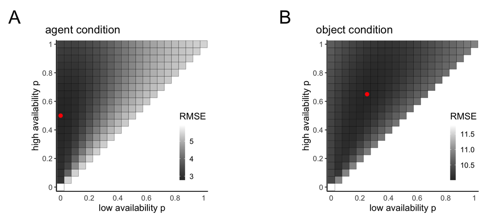

```r
plot_rmse.exp3.agent + plot_spacer() + plot_rmse.exp3.object +
  plot_annotation(tag_levels = 'A') +
  plot_layout(widths = c(4, 1, 4)) &
  theme(plot.tag = element_text(size = 24))
```

```r
# ggsave(paste0(figures_dir, 'experiment3/p_search.pdf'), width = 9, height = 4)
```

### 5.3.2 Setting up data

```r
data.exp3.agent = data.exp3.agent %>%
  cbind(fit.exp3.agent_baseline %>%
          fitted(newdata = data.exp3.agent,
                 re_formula = NA) %>%
          as_tibble() %>%
          mutate(pred_baseline = Estimate) %>%
          select(pred_baseline)) %>%
  cbind(fit.exp3.agent_cp %>%
          fitted(newdata = data.exp3.agent,
                 re_formula = NA) %>%
          as_tibble() %>%
          mutate(pred_cp = Estimate) %>%
          select(pred_cp)) %>%
  cbind(fit.exp3.agent_crm %>%
          fitted(newdata = data.exp3.agent,
                 re_formula = NA) %>%
          as_tibble() %>%
          mutate(pred_crm = Estimate) %>%
          select(pred_crm))

data.exp3.agent_means = data.exp3.agent %>%
  group_by(trial, craft) %>%
  summarise(resp_mean = mean(resp),
            resp_low = smean.cl.boot(resp)[2],
            resp_high = smean.cl.boot(resp)[3]) %>%
  merge(info.exp3.agent, by = c('trial', 'craft')) %>%
  left_join(data.exp3.agent %>%
              distinct(trial, craft, pred_baseline,
                       pred_cp, pred_crm),
            by = c('trial', 'craft'))
```

```r
data.exp3.object = data.exp3.object  %>%
  cbind(fit.exp3.object_baseline %>%
          fitted(newdata = data.exp3.object ,
                 re_formula = NA) %>%
          as_tibble() %>%
          mutate(pred_baseline = Estimate) %>%
          select(pred_baseline)) %>%
  cbind(fit.exp3.object_cp %>%
          fitted(newdata = data.exp3.object ,
                 re_formula = NA) %>%
          as_tibble() %>%
          mutate(pred_cp = Estimate) %>%
          select(pred_cp)) %>%
  cbind(fit.exp3.object_crm %>%
          fitted(newdata = data.exp3.object ,
                 re_formula = NA) %>%
          as_tibble() %>%
          mutate(pred_crm = Estimate) %>%
          select(pred_crm))

data.exp3.object_means = data.exp3.object  %>%
  group_by(trial, color) %>%
  summarise(resp_mean = mean(resp),
            resp_low = smean.cl.boot(resp)[2],
            resp_high = smean.cl.boot(resp)[3]) %>%
  merge(info.exp3.object, by = c('trial', 'color')) %>%
  left_join(data.exp3.object  %>%
              distinct(trial, color, pred_baseline,
                       pred_cp, pred_crm),
            by = c('trial', 'color'))
```

```r
labels.exp3 = info.exp3.agent %>%
  distinct(low, high, availability) %>%
  arrange(low + high, high, desc(availability)) %>%
  mutate(condition = NA,
         index = 1:n(),
         index_prob = rep(1:(n()/2), each = 2),
         grob = pmap(.l = list(availability, low, high),
                     .f = ~ readPNG(paste0(figures_dir, 'experiment3/sets/',
                                          ..1, ..2, ..3, '.png'))))

model_labels.exp3 = c('baseline' = 'Contribution model',
                      'cp' = 'CP model',
                      'crm' = 'CRM-based model')

model_order.exp3 = c('baseline', 'cp', 'crm')
```

### 5.3.3 Scatter plots

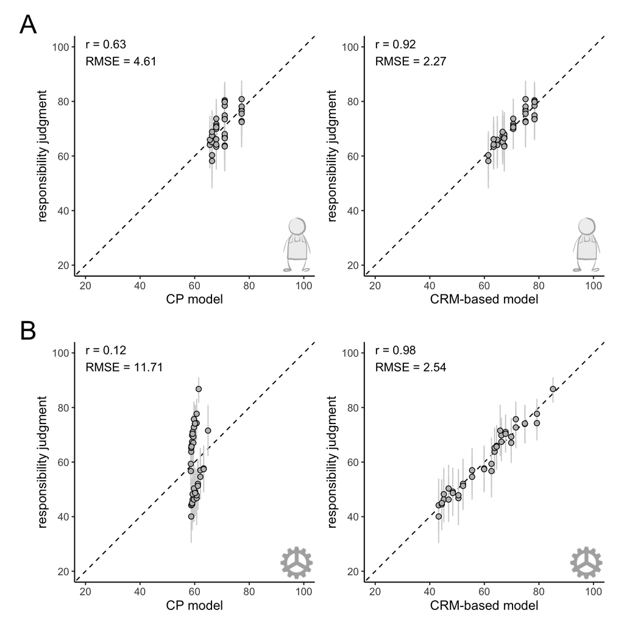

```r
scatter.exp3.agent_cp = make_scatter(
  data.exp3.agent_means, 'cp', 'CP model', seq(20, 100, 20))
scatter.exp3.agent_crm = make_scatter(
  data.exp3.agent_means, 'crm', 'CRM-based model', seq(20, 100, 20))

scatter.exp3.object_cp = make_scatter(
  data.exp3.object_means, 'cp', 'CP model', seq(20, 100, 20))
scatter.exp3.object_crm = make_scatter(
  data.exp3.object_means, 'crm', 'CRM-based model', seq(20, 100, 20))

scatter.exp3.agent_cp + inset_element(agent_icon, 0.85, 0.01, 1, 0.25) +
  scatter.exp3.agent_crm + inset_element(agent_icon, 0.85, 0.01, 1, 0.25) +
  scatter.exp3.object_cp + inset_element(object_icon, 0.85, 0.01, 1, 0.15) +
  scatter.exp3.object_crm + inset_element(object_icon, 0.85, 0.01, 1, 0.15) +
  plot_layout(ncol = 2) +
  plot_annotation(tag_levels = list(c('A', '', '', '',
                                      'B', '', '', ''))) &
  theme(plot.title = element_text(hjust = 0.5),
        plot.tag = element_text(size = 24))
```

```r
# ggsave(paste0(figures_dir, 'experiment3/scatter.pdf'), width = 8, height = 8)
```

### 5.3.4 Bar plots

```r
make_bar.exp3 = function(data, fill) {
  g = ggplot(data = data,
             mapping = aes(x = index,
                           y = resp)) +
    stat_summary(fun = "mean",
                 geom = "bar",
                 color = 'black',
                 fill = fill,
                 width = 0.8) +
    stat_summary(fun.data = "mean_cl_boot",
                 geom = "linerange",
                 size = 1) +
    stat_summary(mapping = aes(y = pred,
                               fill = model,
                               shape = model,
                               size = model),
                 fun = 'mean',
                 geom = 'point',
                 color = 'black',
                 position = position_dodge(width = 0.5)) +
    facet_wrap(~ index, scales = 'free_x', nrow = 2) +
    geom_rect(aes(xmin = index - 0.5, xmax = index + 0.5,
                  ymin = -1, ymax = 19.9),
              fill = 'white') +
    geom_custom(data = labels.exp3,
                mapping = aes(data = grob,
                              x = -Inf, y = 9),
                grob_fun = function(x) rasterGrob(x,
                                                  interpolate = T,
                                                  vjust = 0,
                                                  hjust = 0)) +
    geom_text(aes(label = index,
                  y = 5),
              show.legend = F,
              check_overlap = T) +
    theme(text = element_text(size = 16),
          legend.position = c(0.5, 0.94),
          legend.direction = 'horizontal',
          legend.title = element_blank(),
          axis.title.x = element_blank(),
          axis.text.x = element_blank(),
          axis.line.x = element_blank(),
          axis.ticks.x = element_blank(),
          strip.background = element_blank(),
          strip.text = element_blank(),
          panel.grid.major.y = element_line(),
          panel.spacing.y = unit(1.3, "cm"),
          panel.spacing.x = unit(0.1, "cm"),
          plot.margin = margin(t = 0.2, l = 0.2, r = 0.2, b = 1.3, unit = "cm")) +
    scale_fill_manual(values = c('baseline' = 'black',
                                 'cp' = 'gray50',
                                 'crm' = 'white'),
                      labels = model_labels.exp3,
                      name = 'model') +
    scale_size_manual(values = c('baseline' = 2,
                                 'cp' = 2,
                                 'crm' = 2.5),
                      labels = model_labels.exp3,
                      name = 'model') +
    scale_shape_manual(values = c('baseline' = 21,  # circle
                                  'cp' = 24, # triangle
                                  'crm' = 23), # diamond
                       labels = model_labels.exp3,
                       name = 'model') +
    scale_y_continuous(name = 'responsibility judgment',
                       breaks = seq(20, 100, 20)) +
    coord_cartesian(clip = 'off', ylim = c(20, 100))

  return (g)
}
```

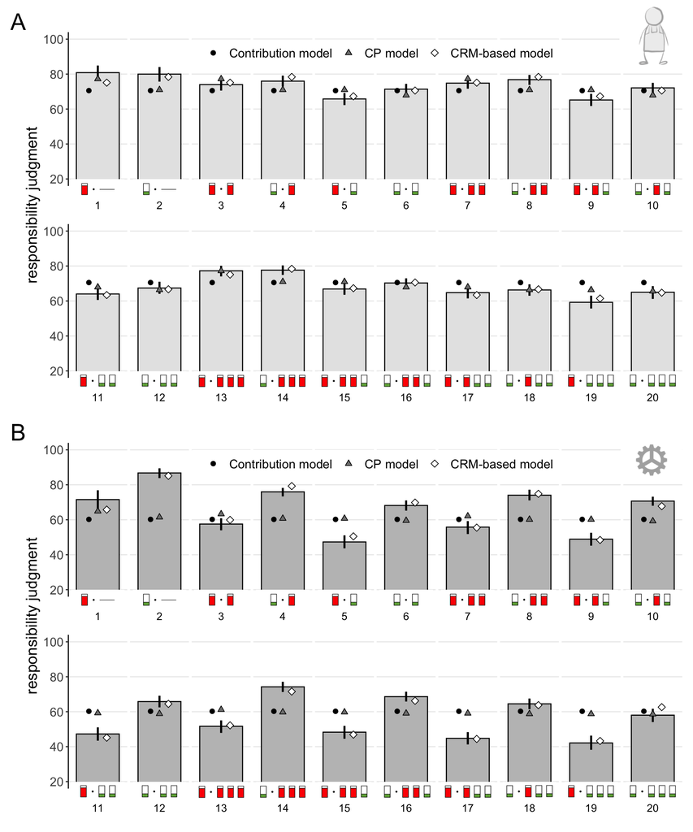

```r
barplot.exp3.agent = make_bar.exp3(
  data = data.exp3.agent %>%
    left_join(labels.exp3 %>%
                select(low, high, availability, index, index_prob),
              by = c('low', 'high', 'availability')) %>%
    pivot_longer(cols = starts_with('pred'),
                 names_to = 'model',
                 values_to = 'pred') %>%
    mutate(model = factor(sub('^pred_', '', model),
                          levels = model_order.exp3)),
  fill = 'gray90'
)

barplot.exp3.object = make_bar.exp3(
  data = data.exp3.object %>%
    left_join(labels.exp3 %>%
                select(low, high, availability, index, index_prob),
              by = c('low', 'high', 'availability')) %>%
    pivot_longer(cols = starts_with('pred'),
                 names_to = 'model',
                 values_to = 'pred') %>%
    mutate(model = factor(sub('^pred_', '', model),
                          levels = model_order.exp3)),
  fill = 'gray75'
)

barplot.exp3.agent + inset_element(agent_icon, 0.9, 0.85, 1, 1, align_to = 'full') +
  barplot.exp3.object + inset_element(object_icon, 0.9, 0.9, 1, 1) +
  plot_layout(ncol = 1) +
  plot_annotation(tag_levels = list(c('A', '', 'B', ''))) &
  theme(plot.tag = element_text(size = 24))
```

```r
# ggsave(paste0(figures_dir, 'experiment3/bar.pdf'), width = 10, height = 12)
```